# Report

RTutor, Powered by ChatGPT

Sun Dec 11 21:09:31 2022

### 1. Generate R code, not R Markdown. Use the mpg data frame. Use ggplot2 to create a boxplot of hwy vs. class. Color by class.

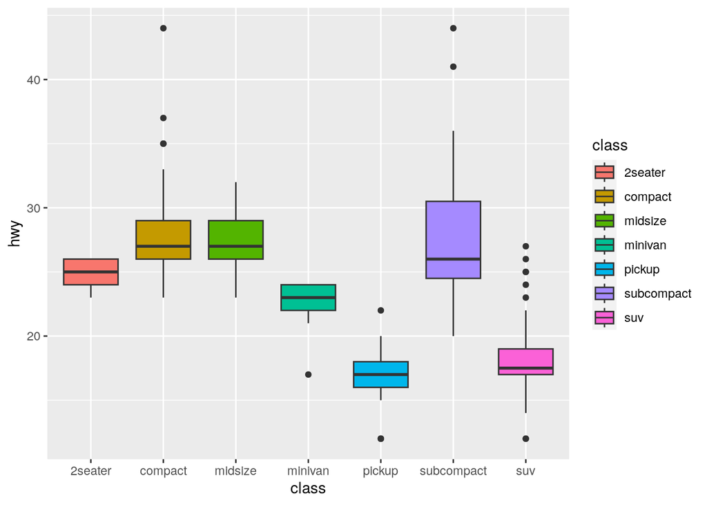

```r
library(ggplot2)
ggplot(mpg, aes(x=class, y=hwy)) + geom_boxplot(aes(fill=class))
```

### 2. Generate R code, not R Markdown. Use the mpg data frame. Create a boxplot of cty vs. class.

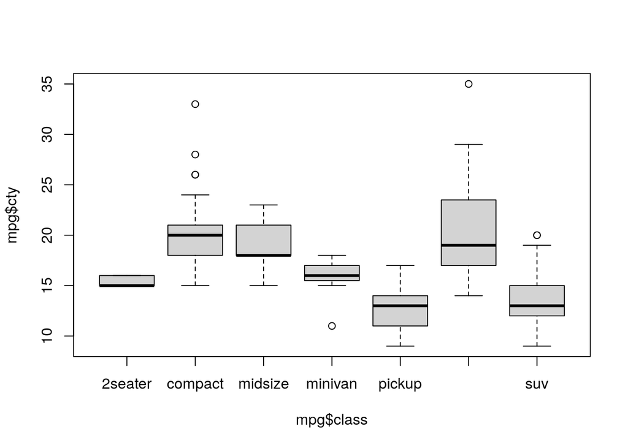

```r
boxplot(mpg$cty ~ mpg$class)
```

### 3. Generate R code, not R Markdown. Use the mpg data frame. Use ggplot2. Plot hwy vs. cty, colored by class. Change shape by drv.

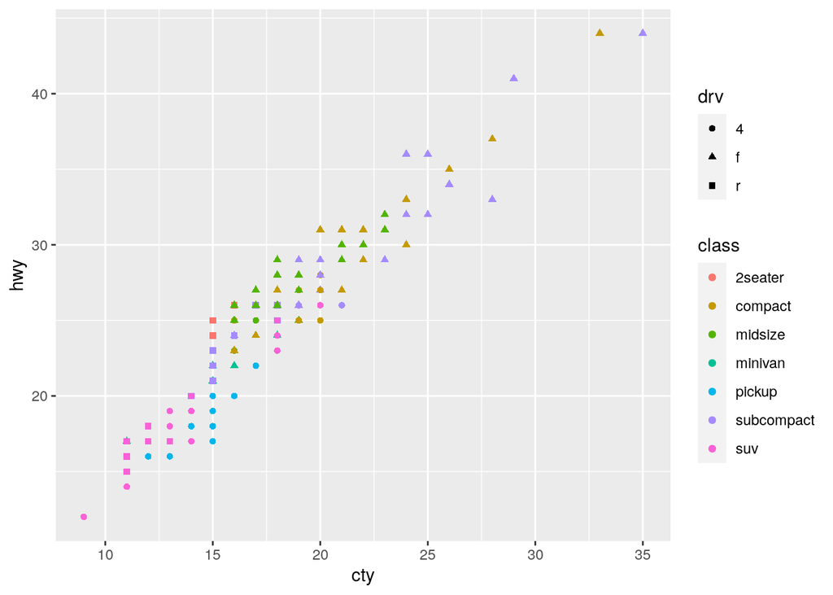

```r
ggplot(data = mpg, aes(x = cty, y = hwy, shape = drv, color = class)) +
  geom_point()
```

### 4. Generate R code, not R Markdown. Use the mpg data frame. Conduct ANOVA of hwy by class.

```r
library(tidyverse)
aov.out <- aov(hwy ~ class, data = mpg)
summary(aov.out)
```

```
##              Df Sum Sq Mean Sq F value Pr(>F)
## class         6   5683   947.2   83.39 <2e-16 ***
## Residuals   227   2578    11.4
## ---
## Signif. codes:  0 '***' 0.001 '**' 0.01 '*' 0.05 '.' 0.1 ' ' 1
```

### 5. Generate R code, not R Markdown. Use the mpg data frame. Use ggplot2 to create a boxplot of hwy vs. class. Color by class.

Add jitter. Remove x label.

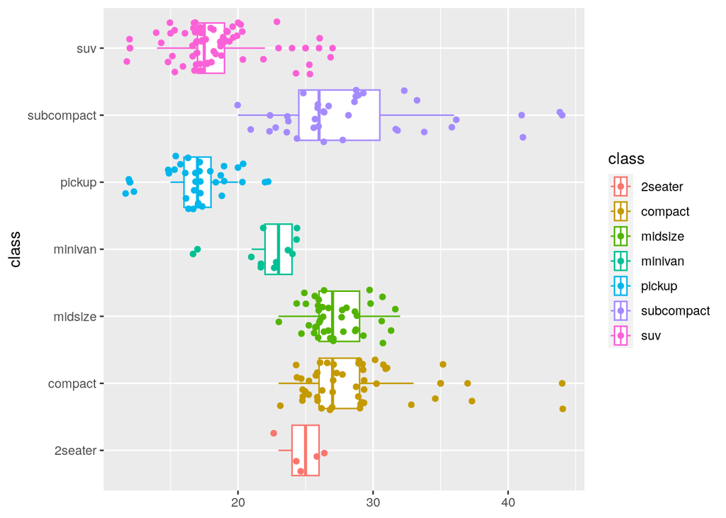

```r
library(ggplot2)
ggplot(mpg, aes(hwy, class, colour=class)) +
  geom_boxplot() +
  geom_jitter() +
  labs(x = NULL)
```

### 6. Generate R code, not R Markdown. Use the mpg data frame. Conduct ANOVA of log-transformed hwy by class and drv.

```r
#Load data
data(mpg)
#Log-transform hwy
mpg$log_hwy = log(mpg$hwy)
#Run ANOVA
anova(lm(log_hwy ~ class * drv, data = mpg))
```

```
## Analysis of Variance Table
##
## Response: log_hwy
##            Df  Sum Sq Mean Sq F value    Pr(>F)
## class       6 11.4771 1.91284 115.415 < 2.2e-16 ***
## drv         2  0.6057 0.30285  18.273 4.504e-08 ***
## class:drv   3  0.0368 0.01226   0.740    0.5292
## Residuals 222  3.6794 0.01657
## ---
## Signif. codes:  0 '***' 0.001 '**' 0.01 '*' 0.05 '.' 0.1 ' ' 1
```

### 7. Generate R code, not R Markdown. Use the mpg data frame. Create a correlation map of all the columns that contain numbers.

```r
corrplot(cor(mpg),type = "upper", tl.srt = 45,col = rainbow(17))
```

** Error **

### 8. Generate R code, not R Markdown. Use the mpg data frame. Create a correlation map of all the columns that contain numbers.

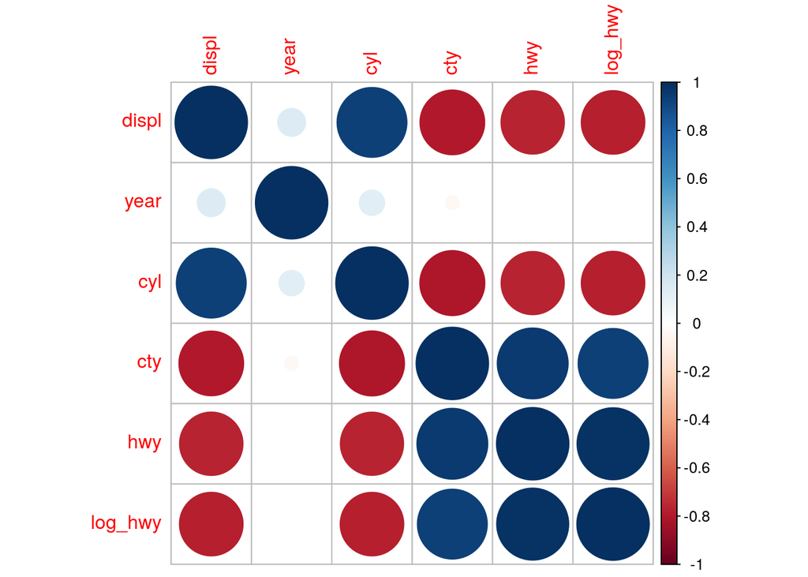

```r
# Generate correlation map
corr_matrix <- cor(mpg[sapply(mpg, is.numeric)])
# Create correlation plot
library(corrplot)
corrplot(corr_matrix)
```

### 9. Generate R code, not R Markdown. Use the mpg data frame. Create a correlation map of all the columns that contain numbers.

```r
# Install corrplot library
#install.packages("corrplot")
library(corrplot)
# Compute correlations
correlations <- cor(mpg)
# Generate correlation map
corrplot(correlations, type="upper", col=colorRampPalette(rev(brewer.pal(9,"Blues")))(200))
```

** Error **

### 10. Generate R code, not R Markdown. Use the mpg data frame. Create a correlation map of all the columns that contain numbers.

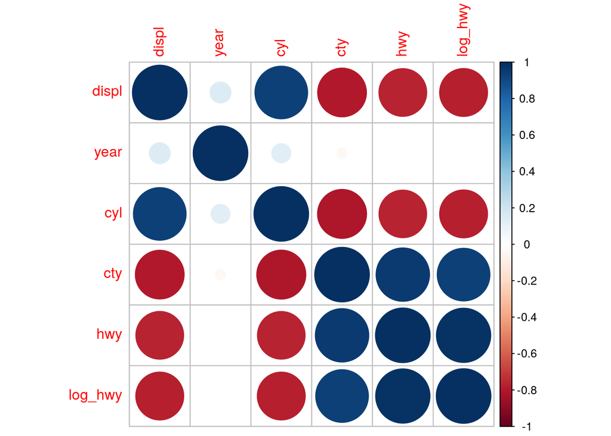

```r
corrplot(cor(mpg[sapply(mpg, is.numeric)]))
```